# act_report

#### Report: act_report

Data wrangling project is about Gathering, Assessing and Cleaning data of dogs rating from WeRateDogs twitter page from different sources , which are : CSV file and TSV file which were downloaded manually from udacity classroom and tweepy to access the data in WeRateDogs using twitter_ids in the WeRateDogs twitter archive in csv then extract retweets and favourites and storing it to tweet_json.txt file. Then reading all those data we gathered and exploring them manually and automatically using (describe , info , some times loops , value_counts .. etc)

I was first so nervous about how to start and from where, but I kept assessing then cleaning and looping through this process untill I put it all together . The hardest part was figuring out how to extract numerators and denominators from text, which I eventually got it. I then started extracting all the data I noticed and clean them using different libraries. I tried to extract some data using sql from spark library using select form method, but it didn't get the needed output with me, so I just took a step back and went back to using python only.  
Finally, I collected all the data into a single dataframe (twitter_archive_master) and used pandas, matplotlib, and seaborn to visualise some of its columns.

## Insights:

1. Distributions of numeric columns.
2. Relationships & Correlation Coefficient between numeric variables.
3. Do we have good 'results' about our predictions?

## Conclusions:

#### (1) Distributions of numeric columns

- We have conf. = 100%, it must be clear picture for a specific breed of dog.
- Some dogs got 0/10 rating, that's weird in such account.
- Most of tweets have only one image.

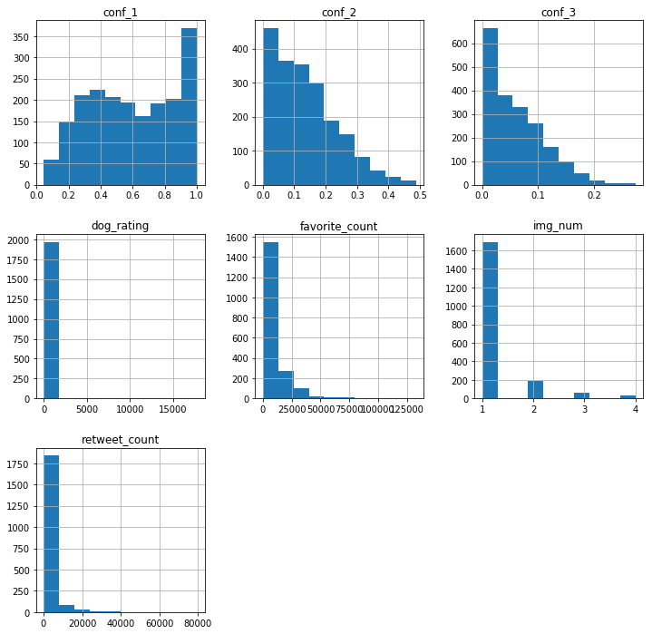

- Most numeric variables have right skewed distribution, that means that the least values have occurred the most.
- We have a good percentage of high prediction cases (> 0.8).
- Most of dog ratings fall between 0 and 200, and we have extreem values reached >17500.

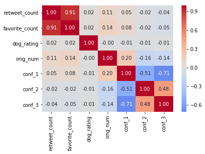